# Question

Un estudiante tiene un vaso de forma cilíndrica. El vaso tiene una base circular de radio 5 cm y una altura de 10 cm, como se muestra en la figura.

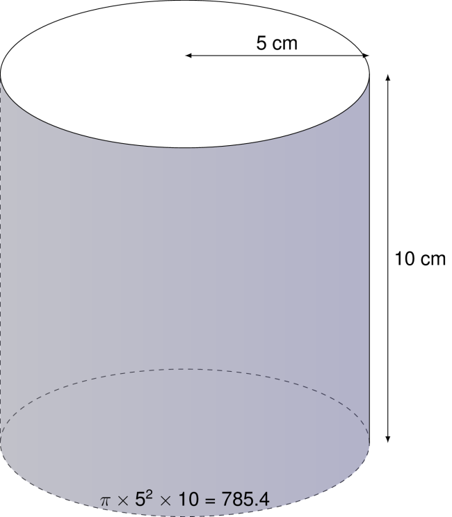

A partir de la información anterior, el estudiante plantea la siguiente operación:

$$\pi \times 5^2 \times 10 =
785.4$$

¿A qué corresponde el resultado de la anterior operación?

## Answerlist

- Al área lateral del vaso: 314.16 cm²
- Al perímetro de la tapa del vaso: 31.42 cm
- Al volumen del vaso: 785.4 cm³
- Al área de la tapa del vaso: 78.54 cm²

# Solution

Para resolver este problema, debemos identificar qué cálculo se está realizando con la fórmula $\pi \times 5^2 \times 10 = 785.4$.

Analizando la fórmula: - $\pi \times r^2$ corresponde al área de la base circular del cilindro - Al multiplicar esta área por la altura $h$, obtenemos el volumen del cilindro

Por lo tanto, la fórmula $V = \pi \times r^2 \times h$ es la fórmula del volumen de un cilindro.

Sustituyendo los valores: - Radio de la base: $r = 5 \text{ cm}$ - Altura: $h = 10 \text{ cm}$

Calculamos: $V = \pi \times (5)^2 \times 10 = \pi \times 25 \times 10 = 785.4 \text{ cm}^3$

El resultado corresponde al volumen del vaso cilíndrico.

## Answerlist

- Falso
- Falso
- Verdadero
- Falso

# Meta-information

exname: Volumen_Cilindro extype: schoice exsolution: 0010 exshuffle: TRUE